# SNA

santosh kumar pandit

2023-05-08

```r
library(igraph)
```

#### 1.Load the attached “termDocMatrix.rdata” file in R/R studio

```r
load("termDocMatrix.rdata")
```

#### 2. Check the structure of this data and comment on it carefully

```r
str(termDocMatrix)
```

```
##  num [1:21, 1:154] 0 0 0 0 1 0 0 0 0 0 ...
##  - attr(*, "dimnames")=List of 2
##   ..$ Terms: chr [1:21] "analysis" "applications" "code" "computing" ...
##   ..$ Docs : chr [1:154] "1" "2" "3" "4" ...
```

This output represents a matrix of dimension 21 by 154, where each element in the matrix is a numeric value. The first line, “[1:21, 1:154]”, indicates that the first dimension of the matrix has 21 rows, while the second dimension has 154 columns.

The matrix is associated with two sets of labels: “Terms” and “Docs”. The “Terms” label has 21 elements, which are the names of the rows in the matrix. The “Docs” label has 154 elements, which are the names of the columns in the matrix.

The value 0 in the matrix means that the corresponding term does not occur in the corresponding document. The value 1 indicates that the term occurs in the corresponding document.

#### 3.Inspect the first 10 rows and first 10 columns of this data using sub-setting

```r
termDocMatrix[1:10, 1:10]
```

```
##               Docs
## Terms          1 2 3 4 5 6 7 8 9 10
##   analysis     0 0 0 0 0 0 0 0 0  0
##   applications 0 0 0 0 0 0 0 0 0  0
##   code         0 0 0 0 0 0 0 0 0  0
##   computing    0 0 1 1 0 1 1 1 1  1
##   data         1 1 0 0 2 0 0 0 0  0
##   examples     0 0 0 0 0 0 0 0 0  0
##   introduction 0 0 0 0 0 0 0 0 0  0
##   mining       0 0 0 0 0 0 0 0 0  0
##   network      0 0 0 0 0 0 0 0 0  0
##   package      0 0 0 1 1 0 0 0 0  0
```

#### 4.convert to matrix

```r
termDocMatrix_mat <- as.matrix(termDocMatrix)
```

#### 5.Change this matrix to a Boolean matrix

```r
termDocMatrix_mat <- termDocMatrix_mat >= 1
```

```r
termMatrix <- t(termDocMatrix) %*% termDocMatrix
```

#### 7. Inspect the first 10 rows and first 10 columns of this matrix using sub-setting

```r
termMatrix[1:10,1:10]
```

```
##     Docs
## Docs 1 2 3 4 5 6 7 8 9 10
##   1  2 2 0 0 2 0 0 0 0  0
##   2  2 3 0 0 2 0 0 0 0  0
##   3  0 0 3 3 1 3 3 3 3  2
##   4  0 0 3 6 3 4 3 3 3  2
##   5  2 2 1 3 7 2 1 1 1  1
##   6  0 0 3 4 2 4 3 3 3  2
##   7  0 0 3 3 1 3 3 3 3  2
##   8  0 0 3 3 1 3 3 4 3  2
##   9  0 0 3 3 1 3 3 3 3  2
##   10 0 0 2 2 1 2 2 2 2  2
```

#### 8. Define a graph object g of termMatrix using graph.adjacency function of “igraph” package with weighted=T and mode=“undirected” arguments in the function

```r
g <- graph.adjacency(termMatrix, weighted = TRUE, mode = "undirected")
```

#### 9. Remove loops of g using simplify function

```r
g <- simplify(g, remove.loops = TRUE)
```

#### 10. Set vertices labels with names of g

```r
V(g)$label <- colnames(termMatrix)
```

#### 11. Set degree with degree of g

```r
V(g)$degree <- degree(g)
```

#### 12. Find degree of g for ’all”, “in” and “out” modes and interpret them carefully

```r
degree_all <- degree(g, mode = "all")
degree_in <- degree(g, mode = "in")
degree_out <- degree(g, mode = "out")
```

the degree of a vertex can be interpreted as a measure of its importance or centrality in the graph, with different modes providing different perspectives on how the vertex is connected to other vertices in the graph.

#### 13. Find diameter of g and interpret it carefully

```r
diameter_g <- diameter(g)
```

The diameter of a graph is a measure of its size, and it indicates the longest shortest path between any pair of vertices in the graph. In other words, it is the maximum number of edges that must be traversed to get from one vertex to another. The diameter is an important measure of the connectivity of a graph, and it is used to study the efficiency of communication or transportation networks, as well as the spread of information or disease in social networks.

#### 14. Find edge density of g and interpret it carefully

```r
edge_density_g <- edge_density(g)
```

#### 15.Find reciprocity of g and interpret it carefully

```r
reciprocity_g <- reciprocity(g)
```

The reciprocity value of the graph is 1, it means that all pairs of vertices that have at least one edge connecting them are mutually connected, that is, there are no pairs of vertices with a directed edge that is not reciprocated.

#### 16. Find closeness of g and interpret it carefully

```r
closeness_g<-closeness(g)
```

The closeness of a vertex in a graph is a measure of how easily that vertex can reach all other vertices in the graph

#### 17. Find betweenness of g and interpret it carefully

```r
betweenness_g<-betweenness(g)
```

#### 18.Plot histogram of node degree and interpret it carefully

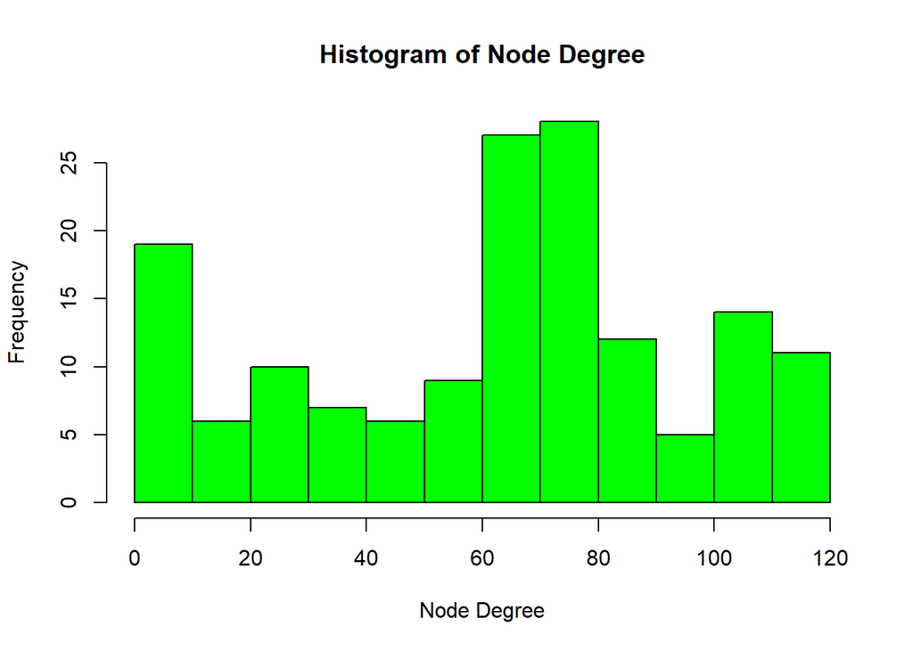

```r
deg <- degree(g)
hist(deg, xlab = "Node Degree", main = "Histogram of Node Degree",col="green")
```

The above histogram show the distribution of range in Node Degree. X-axis represent the range of node degree and Y-axis represents frequency of that values. The highest frequency of node degree lies between 70 to 80 and lowest frequecy of degree of node lies between 90 to 100.

#### 19.Set seed as per your class roll number

```r
set.seed(32)
```

#### 20. plot g with vertex.size of degree*0.4 and interpret it carefully

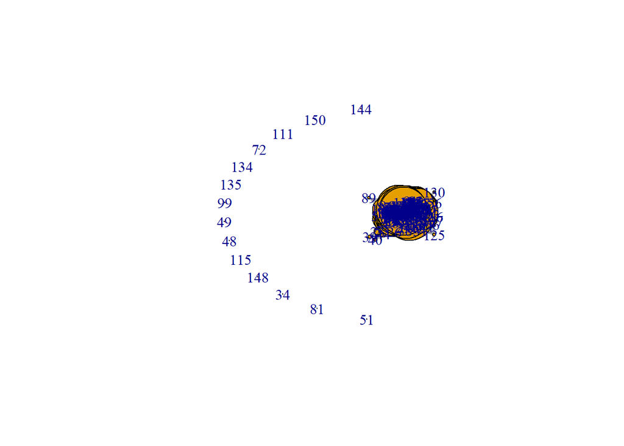

```r
vertex.size <- degree(g) * 0.4
plot(g, vertex.size=vertex.size)
```

#### 21.plot g with fruchterman.reingold layout and interpret it carefully

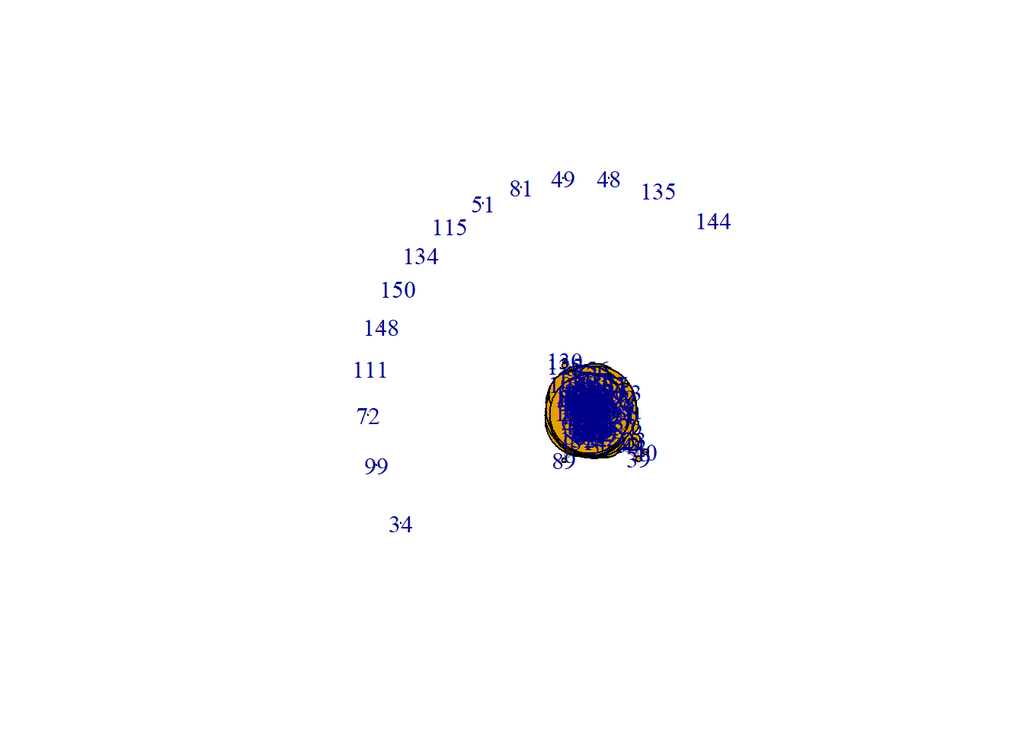

```r
plot(g, layout=layout_with_fr(g), vertex.size=vertex.size)
```

#### 22. plot g with kamada.kawai layout and interpret it carefully

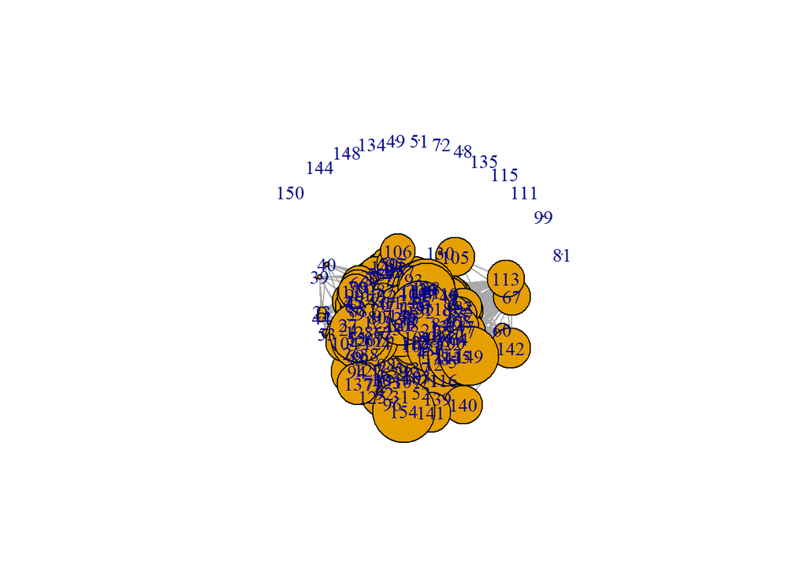

```r
plot(g, layout = layout_with_kk(g), vertex.size = degree(g) * 0.4)
```

#### 23. plot hub and authority of g and interpret them carefully

```r
hub_scores <- as.numeric(unlist(hub_score(g)))
authority_scores <-as.numeric(unlist(authority_score(g)))
```

[figure not shown]

```r
par(mfrow=c(1,2))
plot(hub_scores, main="Hub Scores", xlab="Node", ylab="Score",col="red")
plot(authority_scores, main="Authority Scores", xlab="Node", ylab="Score",col="red")
```

#### 24. Plot community cluster of g and interpret it carefully

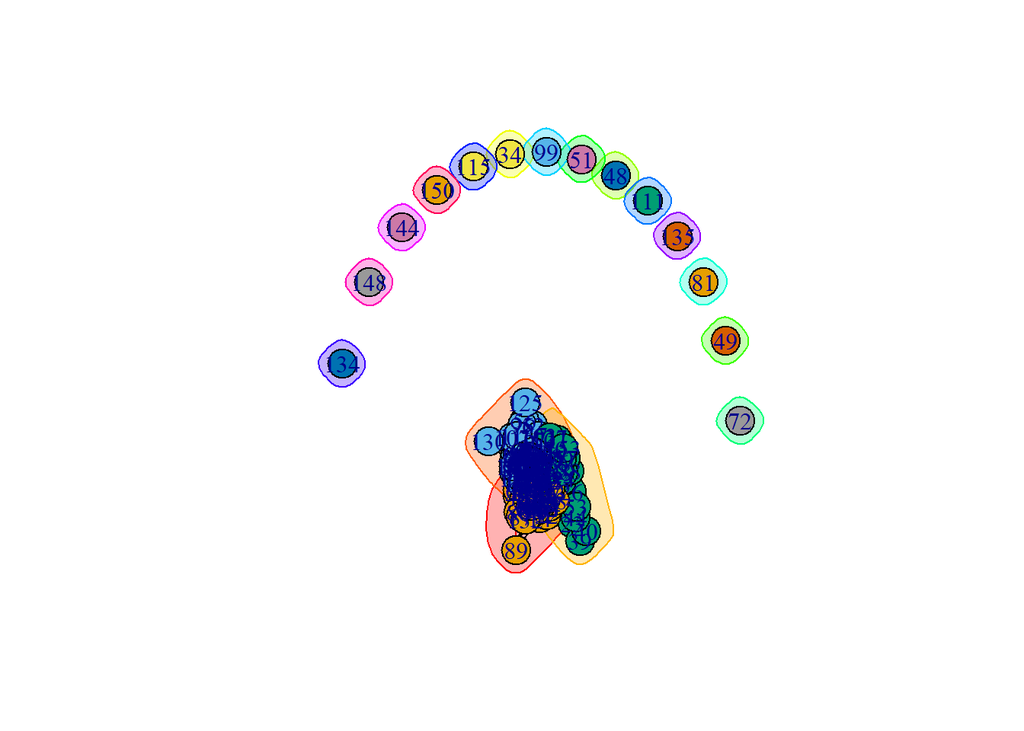

```r
# detect communities using the Louvain algorithm
communities <- cluster_louvain(g)
# plot the community cluster
plot(communities, g)
```